# Análise Univariada para Variáveis Quantitativas usando a base `diamonds`

# Análise Univariada para Variáveis Quantitativas

Nesta aula, vamos explorar visualizações de dados para variáveis contínuas utilizando a base de dados `diamonds` do pacote `ggplot2`. Iniciaremos com gráficos de distribuição de dados, começando pelos histogramas, que são uma maneira fundamental de entender a distribuição de uma variável contínua.

## Carregando Pacotes Necessários

Vamos carregar o pacote `ggplot2`, que já inclui a base de dados `diamonds`.

## Explorando a Base de Dados `diamonds`

A base `diamonds` contém dados sobre diamantes, incluindo o preço (`price`), peso (`carat`), qualidade do corte (`cut`), cor (`color`), e clareza (`clarity`).

```r
glimpse(diamonds)
```

```
Rows: 53,940
Columns: 10
$ carat   <dbl> 0.23, 0.21, 0.23, 0.29, 0.31, 0.24, 0.24, 0.26, 0.22, 0.23, 0.30, 0.23, 0.22, 0.31, 0.20, 0.32, 0.30,…
$ cut     <ord> Ideal, Premium, Good, Premium, Good, Very Good, Very Good, Very Good, Fair, Very Good, Good, Ideal, P…
$ color   <ord> E, E, E, I, J, J, I, H, E, H, J, J, F, J, E, E, I, J, J, J, I, E, H, J, J, G, I, J, D, F, F, F, E, E,…
$ clarity <ord> SI2, SI1, VS1, VS2, SI2, VVS2, VVS1, SI1, VS2, VS1, SI1, VS1, SI1, SI2, SI2, I1, SI2, SI1, SI1, SI1, …
$ depth   <dbl> 61.5, 59.8, 56.9, 62.4, 63.3, 62.8, 62.3, 61.9, 65.1, 59.4, 64.0, 62.8, 60.4, 62.2, 60.2, 60.9, 62.0,…
$ table   <dbl> 55, 61, 65, 58, 58, 57, 57, 55, 61, 61, 55, 56, 61, 54, 62, 58, 54, 54, 56, 59, 56, 55, 57, 62, 62, 5…
$ price   <int> 326, 326, 327, 334, 335, 336, 336, 337, 337, 338, 339, 340, 342, 344, 345, 345, 348, 351, 351, 351, 3…
$ x       <dbl> 3.95, 3.89, 4.05, 4.20, 4.34, 3.94, 3.95, 4.07, 3.87, 4.00, 4.25, 3.93, 3.88, 4.35, 3.79, 4.38, 4.31,…
$ y       <dbl> 3.98, 3.84, 4.07, 4.23, 4.35, 3.96, 3.98, 4.11, 3.78, 4.05, 4.28, 3.90, 3.84, 4.37, 3.75, 4.42, 4.34,…
$ z       <dbl> 2.43, 2.31, 2.31, 2.63, 2.75, 2.48, 2.47, 2.53, 2.49, 2.39, 2.73, 2.46, 2.33, 2.71, 2.27, 2.68, 2.68,…
```

## Visualizando Distribuições com Histogramas

### Histograma Padrão

Vamos começar com um histograma da variável `price` (preço dos diamantes).

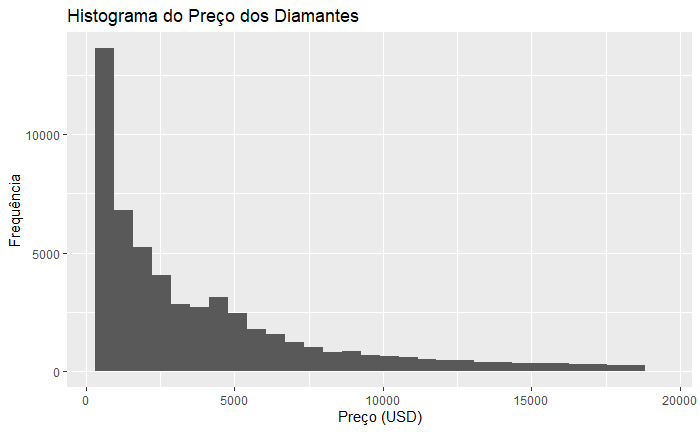

### Explicando os Parâmetros

- **`data = diamonds`**: Estamos utilizando a base de dados `diamonds`.
- **`mapping = aes(x = price)`**: Mapeia a variável `price` no eixo x.
- **`geom_histogram()`**: Cria o histograma, que é a camada geométrica que mapeia a contagem de observações para cada intervalo de valores de `price`.
- **`labs()`**: Adiciona rótulos ao gráfico. `title` define o título, `x` define o rótulo do eixo x, e `y` define o rótulo do eixo y.

### Ajustando o Número de Classes

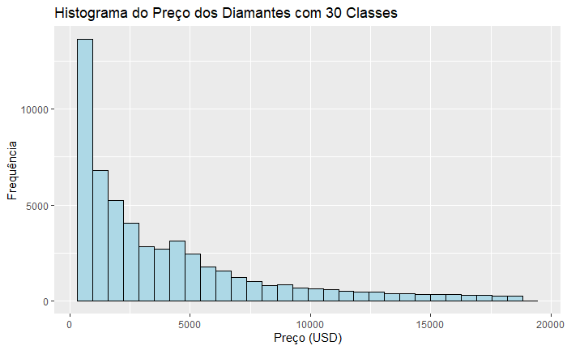

### Adicionando Média e Moda ao Gráfico

Vamos adicionar linhas representando a média e a moda da distribuição de preços.

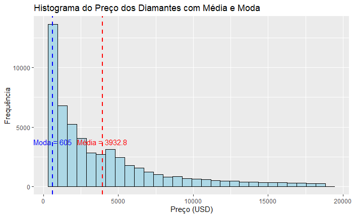

### Explicando os Parâmetros

- **`geom_vline()`**: Adiciona linhas verticais ao gráfico. `xintercept` especifica a posição da linha. Usamos `linetype = "dashed"` para fazer a linha tracejada e `size = 1` para definir a espessura da linha.
- **`annotate()`**: Adiciona texto ao gráfico. `x` e `y` definem a posição do texto, `label` define o texto em si, e `color` define a cor do texto.

### Histograma com Diferentes Números de Classes

Podemos explorar diferentes números de classes (bins) para ver como isso afeta a visualização.

#### Histograma com 12 Classes

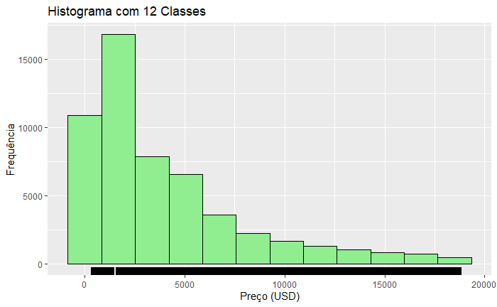

#### Histograma com 50 Classes

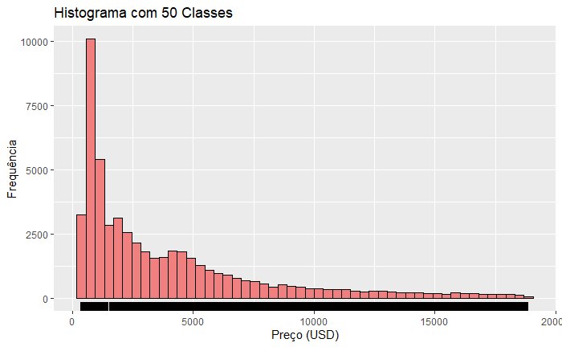

### Explicando o Parâmetro `geom_rug()`

- **`geom_rug()`**: Adiciona pequenas marcas ao longo dos eixos para mostrar a distribuição de dados individuais. Isso é útil para ver onde os dados estão concentrados ao longo do eixo x.

## Visualizando Distribuições com Gráficos de Densidade

### Densidade Kernel

O gráfico de densidade é uma estimativa suave da distribuição dos dados, similar ao histograma, mas com uma curva contínua.

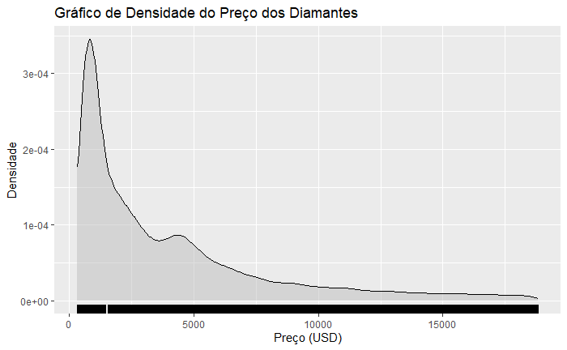

### Explicação do Cálculo da Densidade

- **Densidade Kernel**: Calculada usando uma função “kernel” que suaviza os dados. Cada observação contribui para a estimativa da densidade em torno de si mesma, e a soma dessas contribuições forma a curva.

### Ajustando a Banda do Kernel

Podemos ajustar a largura de banda (bandwidth) do kernel para controlar a suavidade da curva.

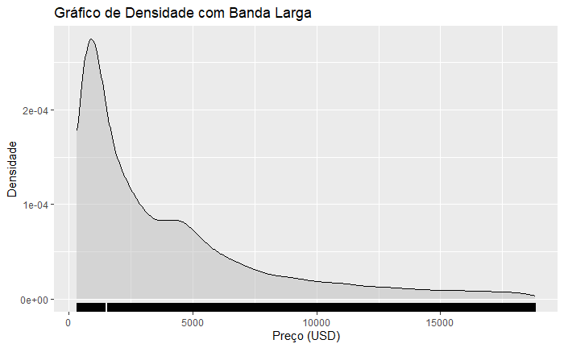

### Comparando Diferentes Kernels

Podemos utilizar diferentes tipos de funções kernel, como “triangular” ou “gaussian”, para alterar a forma da curva.

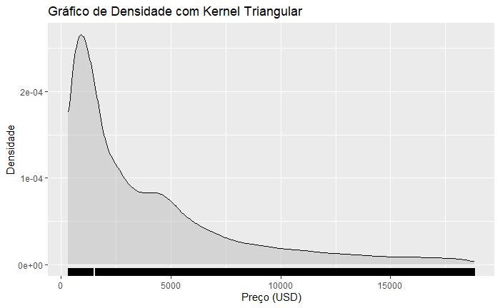

### Adicionando Curva de Distribuição Normal

Podemos sobrepor uma curva de distribuição normal para comparação.

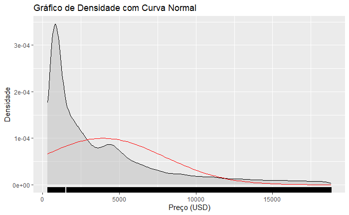

### Explicando `geom_function()`

- **`geom_function()`**: Adiciona uma função matemática ao gráfico. `fun = dnorm` usa a função de densidade normal e `args = list(mean = ..., sd = ...)` especifica os parâmetros da distribuição.